# IODS course project

### Bonus

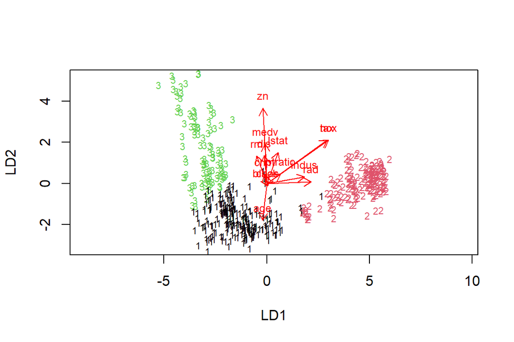

```r
set.seed(2)
data(Boston) # reload dataset
Boston <- Boston %>% scale() # standardize dataset
km3 <- kmeans(Boston, centers = 3) # calculate kmeans
lda.fit2 <- lda(x = Boston, grouping = km3$cluster) # perform discriminant analysis on scaled Boston data providing the groups
plot(lda.fit2, dimen = 2, col = km3$cluster) # plot in biplot
lda.arrows(lda.fit2, myscale = 3) # add arrows
```

Somehow there are issues while knitting the document - afterwards the biplot looks different again:( - I correct it here, hopefully everything will run properly with the next trail of knitting:

# 5: Dimensionality reduction techniques

## This weeks self learning

This week I red the provided chapter 13 from Vehkalahti, Kimmo & Everitt, Brian S. (2019). Additionally, I studied some of the topics from textbooks in my mother thoung because sometimes I struggled with understanding all the new concepts in English. I deepened the learning by doing the Exercise5.Rmd and now feel more or less prepared for doing the assignment 4.

## Tasks in week 5

### Some preparation

I loaded all necessary packages and save some functions in the global environment to avoid issues with identical named functions. Additionally, load the dataset provided in the tasks - to avoid complications with possibly wrong data wrangling task!

```r
# load packages and save some relevant functions
library('tidyverse')
select <- dplyr::select
rename <- dplyr::rename
filter <- dplyr::filter
library('MASS')
library('corrplot')
library('gridExtra')
library('factoextra')
library('cluster')
library('tibble')
library('GGally')
library('FactoMineR')

# set global theme for ggplot
theme_set(theme_test()) # set new 'default' theme for any ggplot

# load data
human <- read_csv("https://raw.githubusercontent.com/KimmoVehkalahti/Helsinki-Open-Data-Science/master/datasets/human2.csv")
```

I load all necessary data for the analysis. The data has been prepared in the data preparation tasks - this is not shown here but rather in the script in my git repository. However, I use the prepared data set from the task to avoid getting troubles from any mistakes in the data preparation.

### Show graphical overview

Afterwards, I changed the column ‘Country’ to row names and explored the data and variables.

```r
# move country names to row names
human <- column_to_rownames(human, "Country")

# data exploration 'human'
dim(human) # 155 observations and 8 variables for each country
```

```
## [1] 155   8
```

```r
names(human) # these are the variables
```

```
## [1] "Edu2.FM"   "Labo.FM"   "Life.Exp"  "Edu.Exp"   "GNI"       "Mat.Mor"
## [7] "Ado.Birth" "Parli.F"
```

```r
str(human) # access the structure of the data
```

```
## 'data.frame':    155 obs. of  8 variables:
##  $ Edu2.FM  : num  1.007 0.997 0.983 0.989 0.969 ...
##  $ Labo.FM  : num  0.891 0.819 0.825 0.884 0.829 ...
##  $ Life.Exp : num  81.6 82.4 83 80.2 81.6 80.9 80.9 79.1 82 81.8 ...
##  $ Edu.Exp  : num  17.5 20.2 15.8 18.7 17.9 16.5 18.6 16.5 15.9 19.2 ...
##  $ GNI      : num  64992 42261 56431 44025 45435 ...
##  $ Mat.Mor  : num  4 6 6 5 6 7 9 28 11 8 ...
##  $ Ado.Birth: num  7.8 12.1 1.9 5.1 6.2 3.8 8.2 31 14.5 25.3 ...
##  $ Parli.F  : num  39.6 30.5 28.5 38 36.9 36.9 19.9 19.4 28.2 31.4 ...
```

```r
summary(human) # print summary statistics for all variables
```

```
##     Edu2.FM          Labo.FM          Life.Exp        Edu.Exp
##  Min.   :0.1717   Min.   :0.1857   Min.   :49.00   Min.   : 5.40
##  1st Qu.:0.7264   1st Qu.:0.5984   1st Qu.:66.30   1st Qu.:11.25
##  Median :0.9375   Median :0.7535   Median :74.20   Median :13.50
##  Mean   :0.8529   Mean   :0.7074   Mean   :71.65   Mean   :13.18
##  3rd Qu.:0.9968   3rd Qu.:0.8535   3rd Qu.:77.25   3rd Qu.:15.20
##  Max.   :1.4967   Max.   :1.0380   Max.   :83.50   Max.   :20.20
##       GNI            Mat.Mor         Ado.Birth         Parli.F
##  Min.   :   581   Min.   :   1.0   Min.   :  0.60   Min.   : 0.00
##  1st Qu.:  4198   1st Qu.:  11.5   1st Qu.: 12.65   1st Qu.:12.40
##  Median : 12040   Median :  49.0   Median : 33.60   Median :19.30
##  Mean   : 17628   Mean   : 149.1   Mean   : 47.16   Mean   :20.91
##  3rd Qu.: 24512   3rd Qu.: 190.0   3rd Qu.: 71.95   3rd Qu.:27.95
##  Max.   :123124   Max.   :1100.0   Max.   :204.80   Max.   :57.50
```

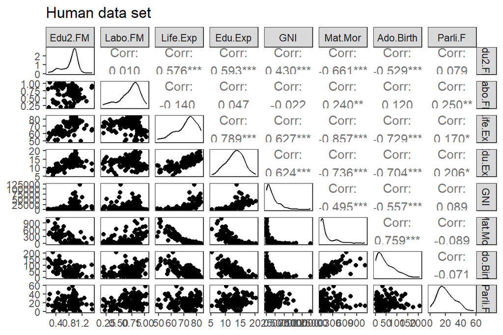

```r
human %>% ggpairs(title = 'Human data set', progress = F)
```

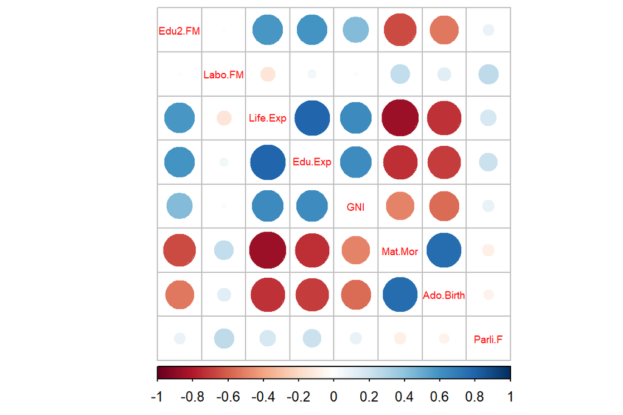

```r
human %>% cor() %>% # provide correlation plot for all variables
  round(digits = 2) %>%
  corrplot(cl.pos = "b", tl.pos = "d", tl.cex = 0.6)
```

1. ‘Edu2.FM’ - Proportion of females with at least secondary education / Proportion of males with at least secondary education; distribution: no certain distribution, but mean of 0.8529
2. ‘Labo.FM’ - Proportion of females in the labour force / Proportion of males in the labour force; distribution: no certain distribution, but mean of 0.7074 and the most values range around 0.8
3. ‘Life.Exp’ - Life expectancy at birth; distribution: no certain distribution, but mean of 71.65 years and there is a min of 49 year and a max of ~83 years
4. ‘Edu.Exp’ - Expected years of schooling; distribution: no certain distribution, but there is a mean of 13.18 years and a min of 5.4 years and a max of 20.2 years - the distribution seems to be ‘centered’
5. ‘GNI’ - Gross National Income per capita; low values are most abundant! the min is 581 and the max is 123124, the mean is relatively low with 17628 - this distribution of income is crazy!
6. ‘Mat.Mor’ - Maternal mortality ratio; low values again very abundant, the min value is 1, the max very high with 1100, the mean is around ~150
7. ‘Ado.Birth’ - Adolescent birth rate, again no certain distribution but low values are more abundant, min of 0.6, mean of 47.16 and max of 204.8
8. ‘Parli.F’- Percentage of female representatives in parliament; no certain distribution, the lowest percentage of women in parliament is 0 :(, the mean is around one fifth of women in parliament and the maximum is more than the half!

The correlation between the variables I briefly name here:

- stronger positive correlation between: Mat.Mor~Ado.Birth, Life.Exp~Edu.Exp, GNI~Life.Exp, GNI~Edu.Exp, Edu2.FM~Life.Exp, Edu2.FM~Edu.Exp
- stronger negative correlation between: Mat.Mor~Life.Exp, Mat.Mor~Edu.Exp, Mat.Mor~GNI, Ado.Birth~Life.Exp, Ado.Birth~Edu.Exp, Ado.Birth~GNI, Edu2.FM~Ado.Birth, Edu2.FM~Mat.Mor

All in all, this means that especially Mat.Mor and Ado.Birth are strongly positively correlated and Life.Exp with Edu.Exp as well as GNI with those two. Especially, the negative correlations are a result from those. Its interesting, that Labo.FM and Parli.F show no (strong) correlations at all.

### Principal component analysis (PCA) - unscaled and scaled data

**unscaled data**

```r
# pca on unscaled (!) dataset 'human'
pca <- prcomp(human)
(s <- summary(pca)) # save and print summary of pca
```

```
## Importance of components:
##                              PC1      PC2   PC3   PC4   PC5   PC6    PC7    PC8
## Standard deviation     1.854e+04 185.5219 25.19 11.45 3.766 1.566 0.1912 0.1591
## Proportion of Variance 9.999e-01   0.0001  0.00  0.00 0.000 0.000 0.0000 0.0000
## Cumulative Proportion  9.999e-01   1.0000  1.00  1.00 1.000 1.000 1.0000 1.0000
```

```r
# compute percentages of variance for variability
pca_pr <- round(100*s$importance[2, ], digits = 2) # compute percentages with 100 or proportions by with 1
pca_pr
```

```
##   PC1   PC2   PC3   PC4   PC5   PC6   PC7   PC8
## 99.99  0.01  0.00  0.00  0.00  0.00  0.00  0.00
```

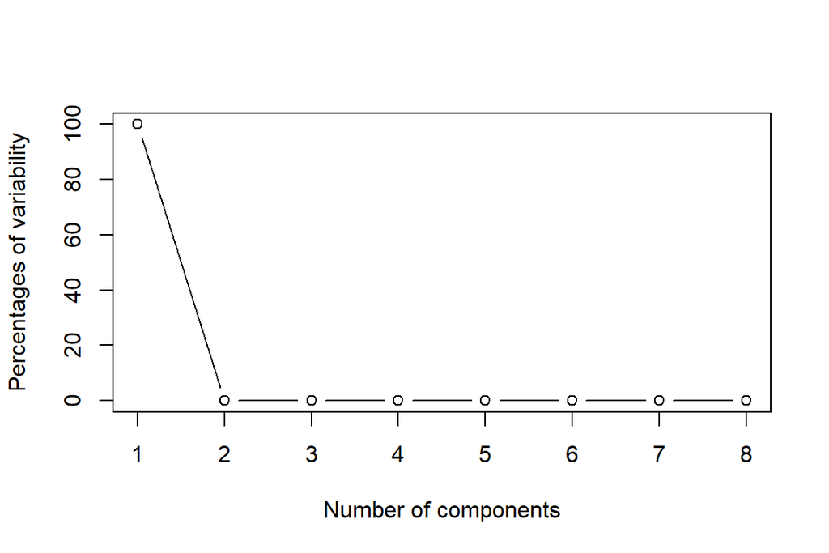

```r
plot(pca_pr, type = 'b', xlab = 'Number of components', ylab = 'Percentages of variability')
```

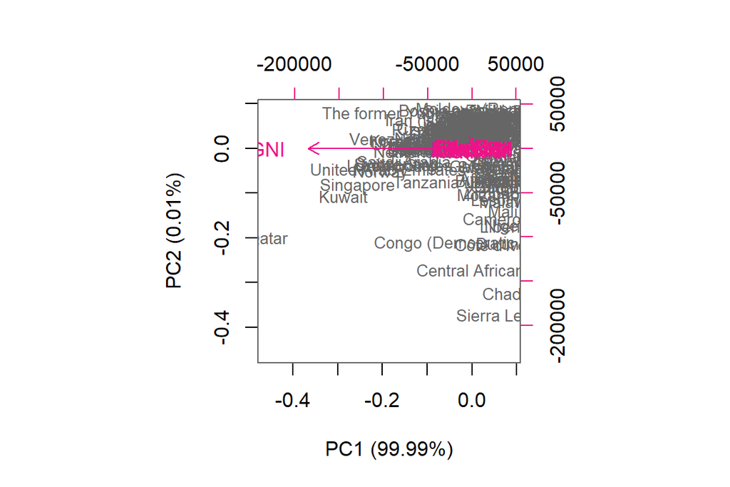

```r
# create object pc_lab to be used as axis labels
pc_lab <- paste0(names(pca_pr), " (", pca_pr, "%)")

# draw a biplot
biplot(pca, cex = c(0.8, 1), col = c("grey40", "deeppink2"), xlab = pc_lab[1], ylab = pc_lab[2])
```

**scaled data**

```r
# pca on scaled dataset 'human'
pca_s <- human %>% scale %>%
  prcomp()
(s_s <- summary(pca_s)) # save and print summary of pca
```

```
## Importance of components:
##                           PC1    PC2     PC3     PC4     PC5     PC6     PC7
## Standard deviation     2.0708 1.1397 0.87505 0.77886 0.66196 0.53631 0.45900
## Proportion of Variance 0.5361 0.1624 0.09571 0.07583 0.05477 0.03595 0.02634
## Cumulative Proportion  0.5361 0.6984 0.79413 0.86996 0.92473 0.96069 0.98702
##                            PC8
## Standard deviation     0.32224
## Proportion of Variance 0.01298
## Cumulative Proportion  1.00000
```

```r
# compute percentages of variance for variability
pca_s_pr <- round(100*s_s$importance[2, ], digits = 2) # compute percentages with 100 or proportions by with 1
pca_s_pr
```

```
##   PC1   PC2   PC3   PC4   PC5   PC6   PC7   PC8
## 53.61 16.24  9.57  7.58  5.48  3.60  2.63  1.30
```

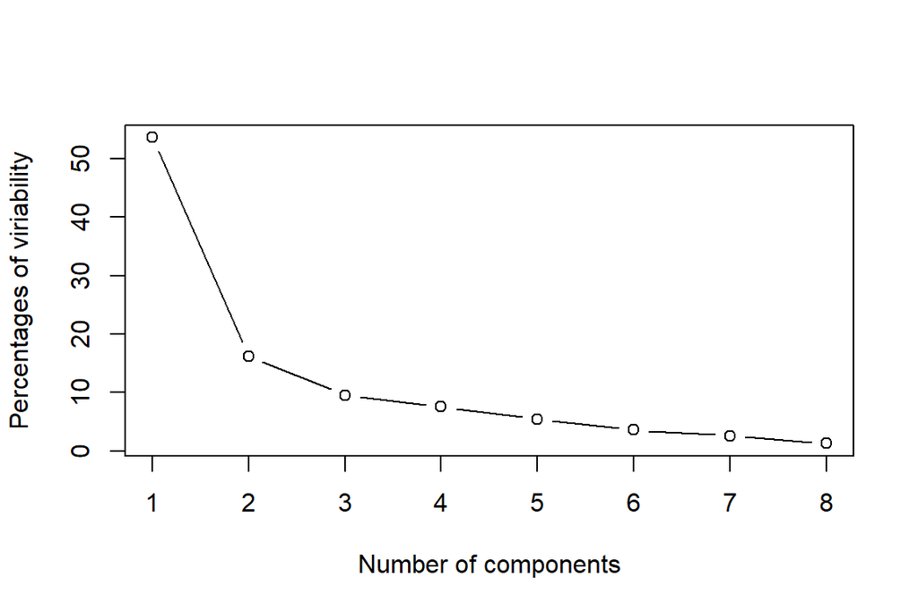

```r
plot(pca_s_pr, type = 'b', xlab = 'Number of components', ylab = 'Percentages of viriability')
```

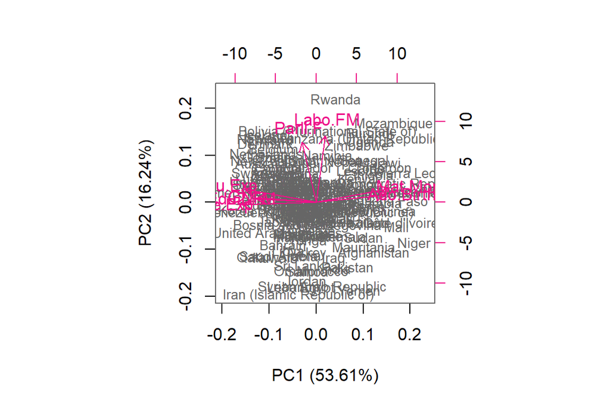

```r
# create object pc_lab to be used as axis labels
pc_s_lab <- paste0(names(pca_s_pr), " (", pca_s_pr, "%)")

# draw a biplot
biplot(pca_s, cex = c(0.8, 1), col = c("grey40", "deeppink2"), xlab = pc_s_lab[1], ylab = pc_s_lab[2])
```

**Interpretation**

One assumption of PCA is that the components are orthogonal to the axes - this seems to be nearly given. Otherwise, ICA could be used.

I’m not sure what is the point of the task ‘Include captions (brief descriptions) in your plots where you describe the results by using not just your variable names’. Here, I briefly describe the meaning of the analysis and try to implement this in the plot:

- Component 1 seems to sum up all the variables describing economic status and wealth - which in consequence could be summarizes by standard of living and wealth.
- Component 2 seems to group variables dealing with gender equality and women rights!

[figure not shown]

```r
# improve plot
biplot(pca_s, cex = c(0.8, 1), col = c("grey40", "deeppink2"),
       xlab = paste0('Living standard/Wealth component - ', pc_s_lab[1]),
       ylab = paste0('Gender equality component - ',pc_s_lab[2]),
       main = 'Principle Components')
```

The next tasks asks for a personal interpretation on the first two principal components. I will try to provide this personal point of view below - even though I already tried to implement this in the previous task. The first principal component consists of variables like Edu.Exp, Edu2.FM, GNI, Ado.Birth and Mat.Mor. I think they are all somehow related to the level of wealth of the country and are used to calculate the HDI. From my understanding, this is a highly weak understanding of ‘development’ if there should be a discussion of ‘development’ at all. This concept currently is under debate - I’m not that much into this topic. However, there is one variable that does not fit that good in the interpretation: Edu2.FM. The other component seems to be more about equality with the variables of Parli.F and Labo.FM which built up the second component. My interpretation of this is that a high level of wealth does not always mean gender and social equality which is so sad. This makes me questioning the current understanding of economic ‘development’ to improve women rights for example.

### Multiple Correspondence Analysis with the tea dataset

First load the data and convert all stringsToFactors = T. Afterwards, explore and visualize the dataset briefly to then perform MCA

```r
# load data
tea <- read.csv("https://raw.githubusercontent.com/KimmoVehkalahti/Helsinki-Open-Data-Science/master/datasets/tea.csv", stringsAsFactors = TRUE)

# explore data
dim(tea) # 300 observations and 36 variables
```

```
## [1] 300  36
```

```r
str(tea) # all variables are factors (2-6 levels), except age: integer
```

```
## 'data.frame':    300 obs. of  36 variables:
##  $ breakfast       : Factor w/ 2 levels "breakfast","Not.breakfast": 1 1 2 2 1 2 1 2 1 1 ...
##  $ tea.time        : Factor w/ 2 levels "Not.tea time",..: 1 1 2 1 1 1 2 2 2 1 ...
##  $ evening         : Factor w/ 2 levels "evening","Not.evening": 2 2 1 2 1 2 2 1 2 1 ...
##  $ lunch           : Factor w/ 2 levels "lunch","Not.lunch": 2 2 2 2 2 2 2 2 2 2 ...
##  $ dinner          : Factor w/ 2 levels "dinner","Not.dinner": 2 2 1 1 2 1 2 2 2 2 ...
##  $ always          : Factor w/ 2 levels "always","Not.always": 2 2 2 2 1 2 2 2 2 2 ...
##  $ home            : Factor w/ 2 levels "home","Not.home": 1 1 1 1 1 1 1 1 1 1 ...
##  $ work            : Factor w/ 2 levels "Not.work","work": 1 1 2 1 1 1 1 1 1 1 ...
##  $ tearoom         : Factor w/ 2 levels "Not.tearoom",..: 1 1 1 1 1 1 1 1 1 2 ...
##  $ friends         : Factor w/ 2 levels "friends","Not.friends": 2 2 1 2 2 2 1 2 2 2 ...
##  $ resto           : Factor w/ 2 levels "Not.resto","resto": 1 1 2 1 1 1 1 1 1 1 ...
##  $ pub             : Factor w/ 2 levels "Not.pub","pub": 1 1 1 1 1 1 1 1 1 1 ...
##  $ Tea             : Factor w/ 3 levels "black","Earl Grey",..: 1 1 2 2 2 2 2 1 2 1 ...
##  $ How             : Factor w/ 4 levels "alone","lemon",..: 1 3 1 1 1 1 1 3 3 1 ...
```

[output cut: 22 more lines]

```r
summary(tea) # hui, thats a lot!
```

```
##          breakfast           tea.time          evening          lunch
##  breakfast    :144   Not.tea time:131   evening    :103   lunch    : 44
##  Not.breakfast:156   tea time    :169   Not.evening:197   Not.lunch:256
##
##
##
##
##
##         dinner           always          home           work
##  dinner    : 21   always    :103   home    :291   Not.work:213
##  Not.dinner:279   Not.always:197   Not.home:  9   work    : 87
##
##
##
##
##
##         tearoom           friends          resto          pub
##  Not.tearoom:242   friends    :196   Not.resto:221   Not.pub:237
##  tearoom    : 58   Not.friends:104   resto    : 79   pub    : 63
##
##
##
##
##
##         Tea         How           sugar                     how
##  black    : 74   alone:195   No.sugar:155   tea bag           :170
##  Earl Grey:193   lemon: 33   sugar   :145   tea bag+unpackaged: 94
##  green    : 33   milk : 63                  unpackaged        : 36
##                  other:  9
##
##
##
##                   where                 price          age        sex
##  chain store         :192   p_branded      : 95   Min.   :15.00   F:178
##  chain store+tea shop: 78   p_cheap        :  7   1st Qu.:23.00   M:122
##  tea shop            : 30   p_private label: 21   Median :32.00
##                             p_unknown      : 12   Mean   :37.05
##                             p_upscale      : 53   3rd Qu.:48.00
##                             p_variable     :112   Max.   :90.00
##
```

[output cut: 25 more lines]

```
##  feminine    :129   Not.sophisticated: 85   No.slimming:255   exciting   :116
##  Not.feminine:171   sophisticated    :215   slimming   : 45   No.exciting:184
##
##
##
##
##
##         relaxing              effect.on.health
##  No.relaxing:113   effect on health   : 66
##  relaxing   :187   No.effect on health:234
##
##
##
##
##
```

```r
#View(tea) # show table in extra window to visualize data

# perform MCA on all variables except from age
mca_full <- MCA(tea %>% select(-age), graph = FALSE) # 'age' causes error, I excluded this variable from analysis
summary(mca_full)
```

```
##
## Call:
## MCA(X = tea %>% select(-age), graph = FALSE)
##
##
## Eigenvalues
##                        Dim.1   Dim.2   Dim.3   Dim.4   Dim.5   Dim.6   Dim.7
## Variance               0.090   0.082   0.070   0.063   0.056   0.053   0.050
## % of var.              5.838   5.292   4.551   4.057   3.616   3.465   3.272
## Cumulative % of var.   5.838  11.130  15.681  19.738  23.354  26.819  30.091
##                        Dim.8   Dim.9  Dim.10  Dim.11  Dim.12  Dim.13  Dim.14
## Variance               0.048   0.047   0.044   0.041   0.040   0.039   0.037
## % of var.              3.090   3.053   2.834   2.643   2.623   2.531   2.388
## Cumulative % of var.  33.181  36.234  39.068  41.711  44.334  46.865  49.252
##                       Dim.15  Dim.16  Dim.17  Dim.18  Dim.19  Dim.20  Dim.21
## Variance               0.036   0.035   0.034   0.032   0.031   0.031   0.030
## % of var.              2.302   2.275   2.172   2.085   2.013   2.011   1.915
## Cumulative % of var.  51.554  53.829  56.000  58.086  60.099  62.110  64.025
##                       Dim.22  Dim.23  Dim.24  Dim.25  Dim.26  Dim.27  Dim.28
## Variance               0.028   0.027   0.026   0.025   0.025   0.024   0.024
## % of var.              1.847   1.740   1.686   1.638   1.609   1.571   1.524
## Cumulative % of var.  65.872  67.611  69.297  70.935  72.544  74.115  75.639
##                       Dim.29  Dim.30  Dim.31  Dim.32  Dim.33  Dim.34  Dim.35
## Variance               0.023   0.022   0.021   0.020   0.020   0.019   0.019
## % of var.              1.459   1.425   1.378   1.322   1.281   1.241   1.222
## Cumulative % of var.  77.099  78.523  79.901  81.223  82.504  83.745  84.967
##                       Dim.36  Dim.37  Dim.38  Dim.39  Dim.40  Dim.41  Dim.42
## Variance               0.018   0.017   0.017   0.016   0.015   0.015   0.014
## % of var.              1.152   1.092   1.072   1.019   0.993   0.950   0.924
## Cumulative % of var.  86.119  87.211  88.283  89.301  90.294  91.244  92.169
##                       Dim.43  Dim.44  Dim.45  Dim.46  Dim.47  Dim.48  Dim.49
## Variance               0.014   0.013   0.012   0.011   0.011   0.010   0.010
## % of var.              0.891   0.833   0.792   0.729   0.716   0.666   0.660
## Cumulative % of var.  93.060  93.893  94.684  95.414  96.130  96.796  97.456
##                       Dim.50  Dim.51  Dim.52  Dim.53  Dim.54
## Variance               0.009   0.009   0.008   0.007   0.006
## % of var.              0.605   0.584   0.519   0.447   0.390
## Cumulative % of var.  98.060  98.644  99.163  99.610 100.000
##
## Individuals (the 10 first)
```

[output cut: 44 more lines]

```
## dinner         0.796  1.805  0.048  3.777 |
## Not.dinner    -0.060  0.136  0.048 -3.777 |
##
## Categorical variables (eta2)
##                 Dim.1 Dim.2 Dim.3
## breakfast     | 0.031 0.000 0.011 |
## tea.time      | 0.240 0.000 0.003 |
## evening       | 0.040 0.087 0.062 |
## lunch         | 0.062 0.029 0.010 |
## dinner        | 0.092 0.000 0.048 |
## always        | 0.056 0.035 0.007 |
## home          | 0.016 0.002 0.030 |
## work          | 0.075 0.020 0.022 |
## tearoom       | 0.321 0.019 0.031 |
## friends       | 0.186 0.061 0.030 |
```

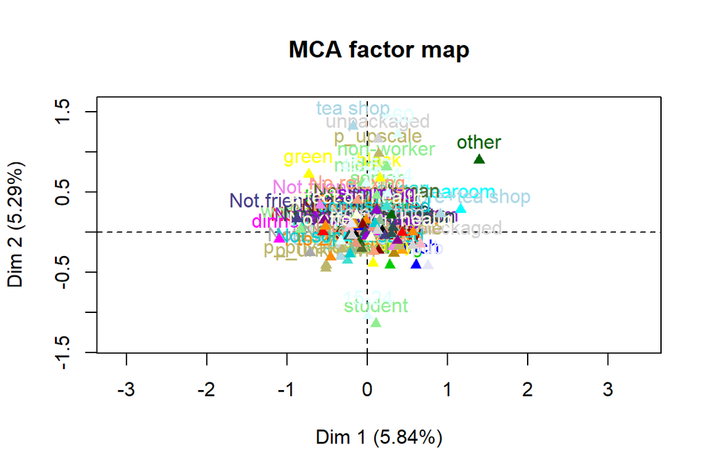

```r
# draw plot
plot(mca_full, invisible=c('ind'), graph.type = "classic", habillage = "quali")
```

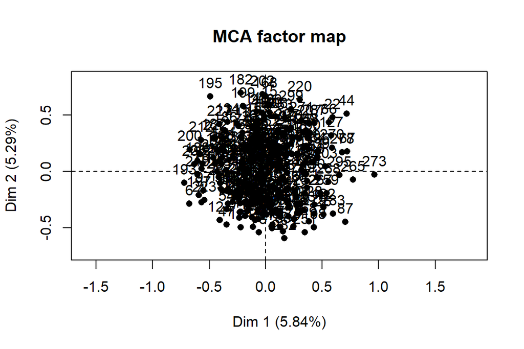

```r
plot(mca_full, invisible=c('var'), graph.type = "classic", habillage = "quali")
```

```r
# select some variables from data set
tea_sel <- tea %>% select(evening, always, friends, How, sex, spirituality, exciting, home)

# perform MCA on selection of variables like in Exercise
mca_sel <- MCA(tea_sel, graph = FALSE) # 'age' causes error, I excluded this variable from analysis
summary(mca_sel)
```

```
##
## Call:
## MCA(X = tea_sel, graph = FALSE)
##
##
## Eigenvalues
##                        Dim.1   Dim.2   Dim.3   Dim.4   Dim.5   Dim.6   Dim.7
## Variance               0.167   0.159   0.141   0.132   0.128   0.121   0.114
## % of var.             13.356  12.739  11.297  10.549  10.211   9.675   9.115
## Cumulative % of var.  13.356  26.095  37.392  47.942  58.153  67.827  76.943
##                        Dim.8   Dim.9  Dim.10
## Variance               0.103   0.096   0.089
## % of var.              8.246   7.681   7.130
## Cumulative % of var.  85.189  92.870 100.000
##
## Individuals (the 10 first)
##                Dim.1    ctr   cos2    Dim.2    ctr   cos2    Dim.3    ctr
## 1           | -0.705  0.993  0.658 | -0.032  0.002  0.001 |  0.042  0.004
## 2           | -0.567  0.643  0.272 |  0.320  0.215  0.087 | -0.455  0.489
## 3           |  0.135  0.036  0.027 | -0.573  0.687  0.495 |  0.354  0.296
## 4           | -0.427  0.363  0.187 |  0.192  0.077  0.038 | -0.085  0.017
## 5           |  0.204  0.083  0.032 |  0.141  0.042  0.015 | -0.041  0.004
## 6           | -0.705  0.993  0.658 | -0.032  0.002  0.001 |  0.042  0.004
## 7           | -0.270  0.145  0.124 | -0.172  0.062  0.050 |  0.127  0.038
## 8           | -0.350  0.244  0.099 | -0.215  0.096  0.037 | -0.279  0.183
## 9           | -0.754  1.136  0.491 |  0.187  0.073  0.030 | -0.505  0.603
## 10          | -0.406  0.329  0.178 | -0.099  0.020  0.010 |  0.253  0.152
##               cos2
## 1            0.002 |
## 2            0.175 |
## 3            0.189 |
## 4            0.007 |
## 5            0.001 |
## 6            0.002 |
## 7            0.028 |
## 8            0.063 |
## 9            0.220 |
## 10           0.069 |
##
## Categories (the 10 first)
```

[output cut: 18 more lines]

```
## alone       |   0.404   9.397   0.303   9.523 |
## lemon       |   0.355   1.230   0.016   2.161 |
## milk        |  -1.242  28.676   0.410 -11.073 |
## other       |  -1.365   4.949   0.058  -4.151 |
##
## Categorical variables (eta2)
##                Dim.1 Dim.2 Dim.3
## evening      | 0.215 0.010 0.091 |
## always       | 0.266 0.001 0.057 |
## friends      | 0.459 0.045 0.015 |
## How          | 0.145 0.223 0.500 |
## sex          | 0.029 0.275 0.001 |
## spirituality | 0.179 0.110 0.032 |
## exciting     | 0.017 0.530 0.003 |
## home         | 0.027 0.081 0.433 |
```

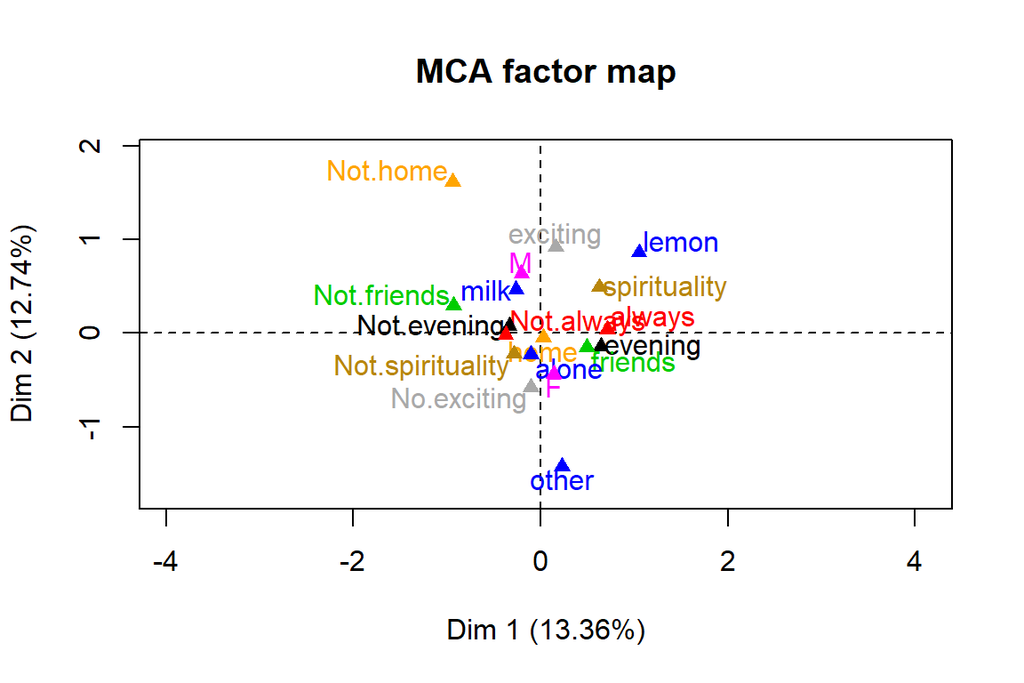

```r
# draw plot
plot(mca_sel, invisible=c('ind'), graph.type = "classic", habillage = "quali")
```

```r
#plot(mca_sel, invisible=c('var'), graph.type = "classic", habillage = "quali")

# other possebilities for visualization - add code
```

I will focus on the analysis of the tea subset because the tea full dataset MCA biplot looks a bit messy and overwhelming to me. This is the last shown plot: All in all, only about 25 % of the total inertia is explained. The first dimension seems to account for ~13 % and the second for 12 % of the inertia. Thus, the adequacy of the fit should be addressed in more detail and maybe more dimensions should be analysed. More in detail, the categories of different columns/variables that are placed next to each other somehow seem to be related to each other - they ‘share a pattern’ in their factors. Its not easy to interpret this in the current example. Even though, I will have a try: for example ‘lemon’ tea, I certain amount of ‘spirituality’ and exciting seems to be a kind of associated to each other and this is then done regularly ‘always’. Additionally, drinking tea in the ‘evening’ together with ‘friends’ seems to be a common thing. Furthermore, all the ‘not’ variables are sharing a pattern (or the pattern are not that different): Drinking tea without friends, not in the evening only rarely and without any kind of spirituality is placed next to each other. ‘Other’ ways of drinking tea in terms of the added spices or milk etc. is somehow not associated with any other variable patter as well as drinking tea not at home.

My interpretation was mainly based on this notes from the book Vehkalahti, Kimmo & Everitt, Brian S. (2019). ‘Accordingly, column points that are close together indicate columns with similar profiles down the rows. Finally, row points that lie close to column points represent a row/column combination that occurs more frequently in the table than would be expected if the row and column variables were independent. Conversely, row and column points that are distant from one another indicate a cell in the table where the count is lower than would be expected under independence.’

# 6: Analysis of longitudinal data

## This weeks self learning

This week I red the provided chapter 8 and 9 from Vehkalahti, Kimmo & Everitt, Brian S. (2019). Additionally, I studied some of the topics from textbooks in my mother lamguage because sometimes I struggled with understanding all the new concepts in English. I deepened the learning by doing the Exercise6.Rmd and now feel more or less prepared for doing the assignment 6.

## Some preparation

I loaded all necessary packages and save some functions in the global environment to avoid issues with identical named functions. Additionally, load the data sets I already prepared in the data wrangling tasks. NB: I had to factorize some variables again.

```r
# load packages and save some relevant functions
library('tidyverse')
select <- dplyr::select
rename <- dplyr::rename
filter <- dplyr::filter
library('MASS')
library('corrplot')
library('gridExtra')
library('factoextra')
library('cluster')
library('tibble')
library('GGally')
library('FactoMineR')
library(plotrix)
library(lme4)

# set global theme for ggplot
theme_set(theme_test()) # set new 'default' theme for any ggplot

# load data
RATSL <- read.csv(file = 'C:/Users/filib/Documents/Studium/Semester 7 (Erasmus)/Introduction to Open Data Science/IODS-project/data/ratsl_data.csv')
BPRSL <- read.csv(file = 'C:/Users/filib/Documents/Studium/Semester 7 (Erasmus)/Introduction to Open Data Science/IODS-project/data/bprsl_data.csv')

# factorise data and remove X column
RATSL <- RATSL %>%
  mutate(ID = as.factor(ID), Group = as.factor(Group)) %>%
  select(-X)
BPRSL <- BPRSL %>%
  mutate(treatment = as.factor(treatment), subject = as.factor(subject)) %>%
  select(-X)
```

## Work on chapter 8 and the Meet and Repeat 1 but with a different dataset: RATSL

### Data exploration and graphical display of longitudinal data

```r
# some general data exploration like in data wrangling task
head(RATSL)
```

```
##   ID Group  WD Weight Time
## 1  1     1 WD1    240    1
## 2  2     1 WD1    225    1
## 3  3     1 WD1    245    1
## 4  4     1 WD1    260    1
## 5  5     1 WD1    255    1
## 6  6     1 WD1    260    1
```

```r
str(RATSL)
```

```
## 'data.frame':    176 obs. of  5 variables:
##  $ ID    : Factor w/ 16 levels "1","2","3","4",..: 1 2 3 4 5 6 7 8 9 10 ...
##  $ Group : Factor w/ 3 levels "1","2","3": 1 1 1 1 1 1 1 1 2 2 ...
##  $ WD    : chr  "WD1" "WD1" "WD1" "WD1" ...
##  $ Weight: int  240 225 245 260 255 260 275 245 410 405 ...
##  $ Time  : int  1 1 1 1 1 1 1 1 1 1 ...
```

```r
summary(RATSL)
```

```
##        ID      Group       WD                Weight           Time
##  1      : 11   1:88   Length:176         Min.   :225.0   Min.   : 1.00
##  2      : 11   2:44   Class :character   1st Qu.:267.0   1st Qu.:15.00
##  3      : 11   3:44   Mode  :character   Median :344.5   Median :36.00
##  4      : 11                             Mean   :384.5   Mean   :33.55
##  5      : 11                             3rd Qu.:511.2   3rd Qu.:50.00
##  6      : 11                             Max.   :628.0   Max.   :64.00
##  (Other):110
```

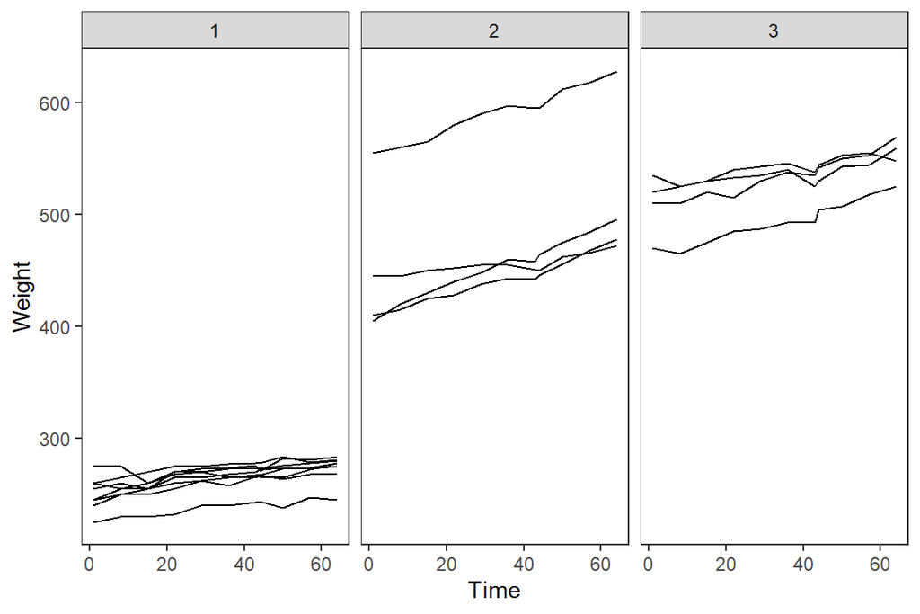

```r
# show graphical overview by plots
RATSL %>% ggplot(aes(x = Time, y = Weight, group = ID)) +
  geom_line() +
  facet_wrap(~Group)
```

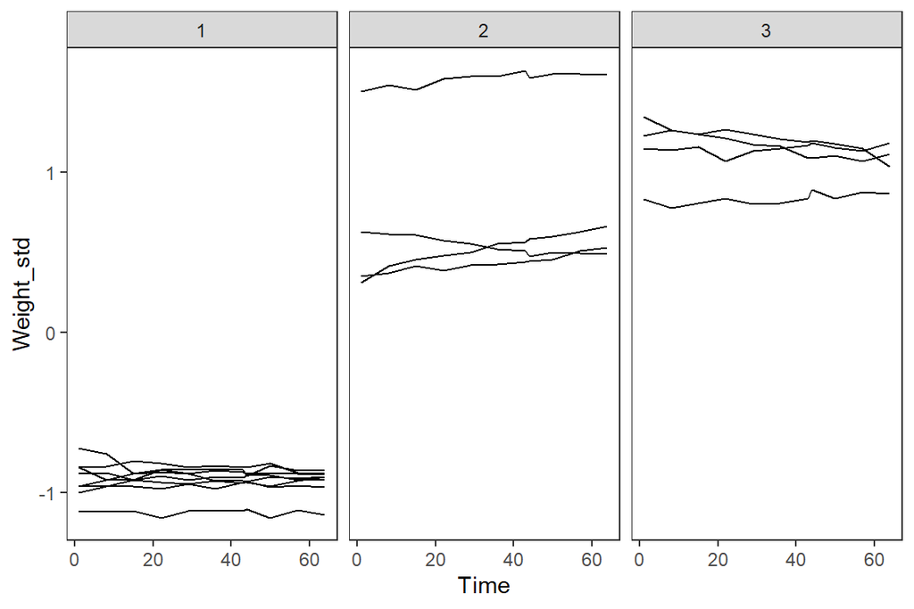

```r
# standardize data
RATSL <- RATSL %>%
  group_by(Time) %>%
  mutate(Weight_std = scale(Weight)) %>% # is the same like scale()
  ungroup()

# show graphical overview for standardized data
RATSL %>% ggplot(aes(x = Time, y = Weight_std, group = ID)) +
  geom_line() +
  facet_wrap(~Group)
```

I plotted a graphical overview on the data - one time with the actual values and one other graph with the standardized data within each ‘time’. The plots with standardized weights show highly different thing: The weight seems to stay more or less constand in Group 1, seems to increase on a high level in Group 2 and seems to decrease in Group 3. In comparison, the unstandardized data shows increasing weights over all Groups.

### Summary statistics

```r
# compute summaries
RATSLS <- RATSL %>%
  group_by(Group, Time) %>%
  summarise(mean = mean(Weight), se = std.error(Weight)) %>%
  ungroup()
```

```r
# plot
# ggplot() +
#  geom_line(data = RATSL, mapping = aes(x = Time, y = Weight, group = ID)) +
#  geom_errorbar(data = RATSLS, mapping = aes(ymin=mean-se, ymax=mean+se, linetype="1"), width=0.3) +
#  facet_wrap(~Group)
```

Somehow there are issues in plotting the errorbars in ggplot - I’m not really able to fix this issue:/

### Search for outliers in the data by applying boxplots

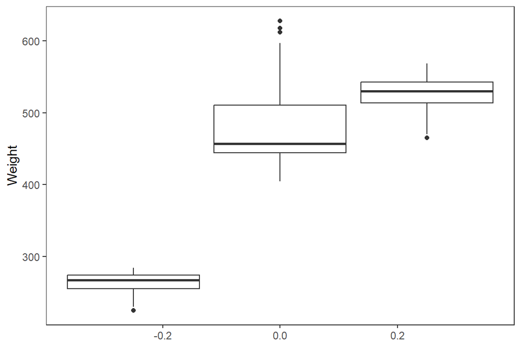

```r
# draw boxplots for each Group
RATSL %>% ggplot(aes(y = Weight, group = Group)) +
  geom_boxplot()
```

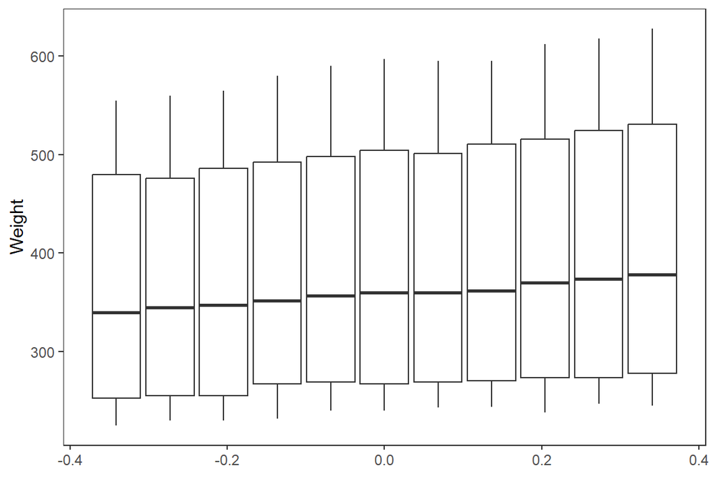

```r
# draw boxplots for each Time
RATSL %>% ggplot(aes(y = Weight, group = Time)) +
  geom_boxplot()
```

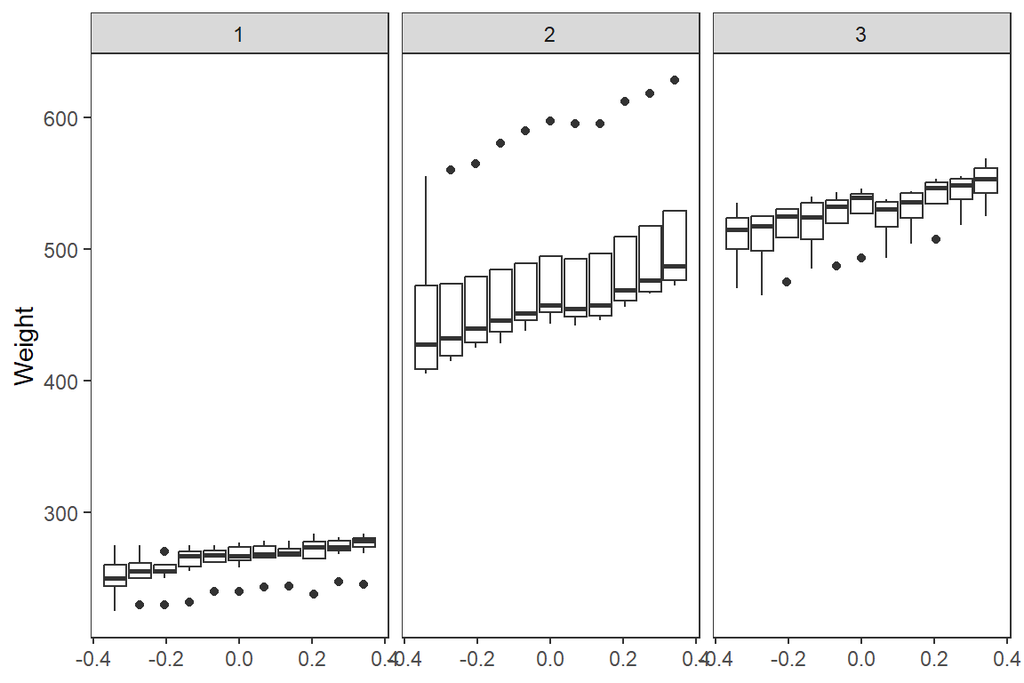

```r
# draw boxplots for each Time and Group
RATSL %>% ggplot(aes(y = Weight, group = Time)) +
  geom_boxplot() +
  facet_wrap(~Group)
```

It has been hard for me to search for outliers - especially, because from my understanding its not really justified to simply exclude outliers without having a sufficient explanation/reason to do this. If the data is not good enough, statistics shouldn’t be used to make the data prettier. However, in the first plots are outliers visible from the points in each group. In plot two do not appear any outlier and in plot 3 are again outliers visible. Only the last plots provides an idea, that maybe measurements for some individuals (ID) seem to be baised by any errors and possibly they could be excluded. Nevertheless, I wont do this here due to a lack of information about possible errors and thus not enough justification for removing data.

### T-test and Anova

```r
# t-test
# t.test(mean ~ Group, data = RATSLS)

# fit lm
fit <- lm(Weight ~ Group + Time, data = RATSL)
summary(fit)
```

```
##
## Call:
## lm(formula = Weight ~ Group + Time, data = RATSL)
##
## Residuals:
##     Min      1Q  Median      3Q     Max
## -60.643 -24.017   0.697  10.837 125.459
##
## Coefficients:
##             Estimate Std. Error t value Pr(>|t|)
## (Intercept) 244.0689     5.7725  42.281  < 2e-16 ***
## Group2      220.9886     6.3402  34.855  < 2e-16 ***
## Group3      262.0795     6.3402  41.336  < 2e-16 ***
## Time          0.5857     0.1331   4.402 1.88e-05 ***
## ---
## Signif. codes:  0 '***' 0.001 '**' 0.01 '*' 0.05 '.' 0.1 ' ' 1
##
## Residual standard error: 34.34 on 172 degrees of freedom
## Multiple R-squared:  0.9283, Adjusted R-squared:  0.9271
## F-statistic: 742.6 on 3 and 172 DF,  p-value: < 2.2e-16
```

```r
# compute table of variance
anova(fit)
```

```
## Analysis of Variance Table
##
## Response: Weight
##            Df  Sum Sq Mean Sq  F value    Pr(>F)
## Group       2 2604050 1302025 1104.197 < 2.2e-16 ***
## Time        1   22847   22847   19.375  1.88e-05 ***
## Residuals 172  202816    1179
## ---
## Signif. codes:  0 '***' 0.001 '**' 0.01 '*' 0.05 '.' 0.1 ' ' 1
```

Firstly, it seems to be not possible to perform a t-test on the data because there are more than 2 groups. Thus, I directly moved forward applying the lm and ANOVA. The linear model showed that both treatments in group 2 and 3 had a significant positive influence on the weight (p-value much below 0.05). Furthermore, the Time had a significant positive impact too.

## Work on chapter 9 and the Meet and Repeat 2 but with a different dataset: BPRS

### plots

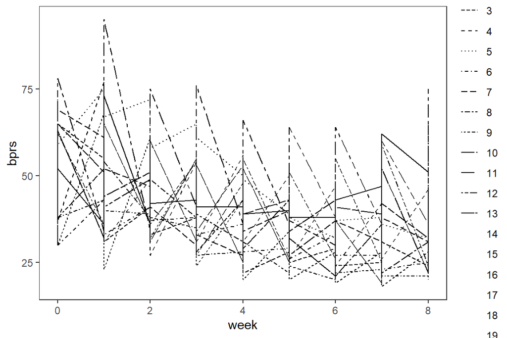

```r
# plot ignoring the longitudinal structure
ggplot(BPRSL, aes(x = week, y = bprs, linetype = subject)) +
  geom_line()
```

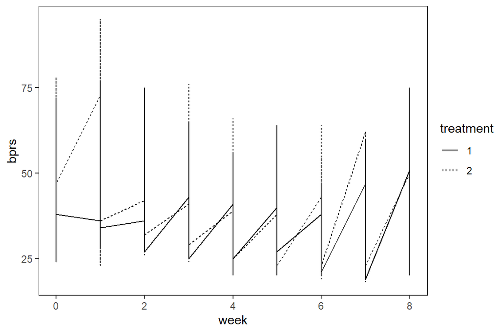

```r
# another plot ignoring the longitudinal structure
ggplot(BPRSL, aes(x = week, y = bprs, linetype = treatment)) +
  geom_line()
```

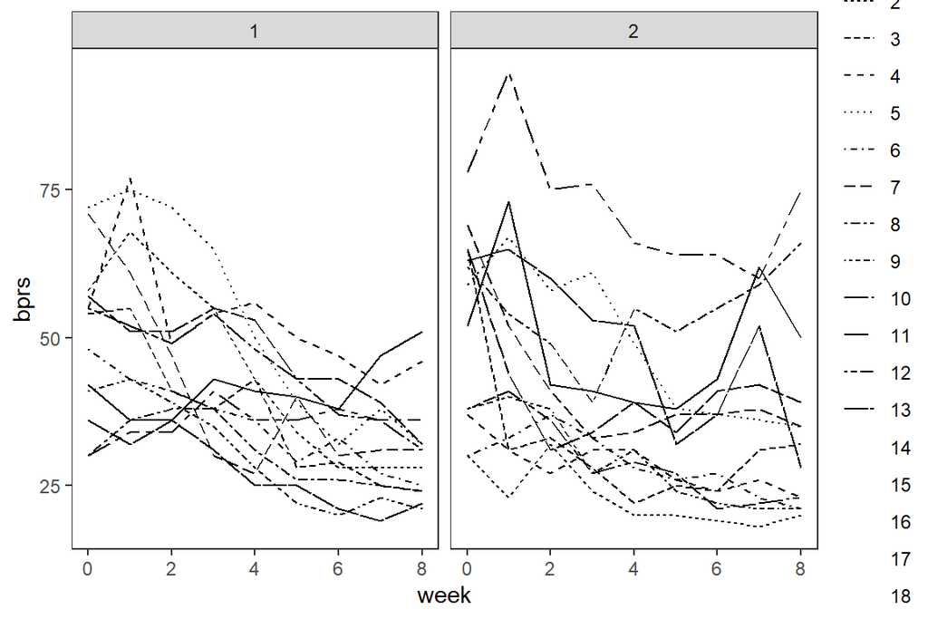

```r
# plot
ggplot(BPRSL, aes(x = week, y = bprs, linetype = subject)) +
  geom_line() +
  facet_wrap(~treatment)
```

I built some line plots with the first trying to ignore the longitudinal structure - this not really is useful. Afterwards, I splitted the data by treatment and some good plots appear.

### Linear model

```r
# fit linear model ignoring the longitudinal structure
BPRSL_reg <- lm(formula = bprs ~ week + treatment, data = BPRSL)
summary(BPRSL_reg) # print model summary
```

```
##
## Call:
## lm(formula = bprs ~ week + treatment, data = BPRSL)
##
## Residuals:
##     Min      1Q  Median      3Q     Max
## -22.454  -8.965  -3.196   7.002  50.244
##
## Coefficients:
##             Estimate Std. Error t value Pr(>|t|)
## (Intercept)  46.4539     1.3670  33.982   <2e-16 ***
## week         -2.2704     0.2524  -8.995   <2e-16 ***
## treatment2    0.5722     1.3034   0.439    0.661
## ---
## Signif. codes:  0 '***' 0.001 '**' 0.01 '*' 0.05 '.' 0.1 ' ' 1
##
## Residual standard error: 12.37 on 357 degrees of freedom
## Multiple R-squared:  0.1851, Adjusted R-squared:  0.1806
## F-statistic: 40.55 on 2 and 357 DF,  p-value: < 2.2e-16
```

The linear regression analysis ignoring the longitudinal data structure shows that treatment 2 dependent on the variable week does not differ significantly from treatment 1 - because of a p-value of 0.661. In comparison to this, the variable week seems to have a negative impact on bprs value that is highly significant.

### Random Intercept model and random Inetercept and Random Slope Model

```r
# fit random intercept model
BPRSL_ref <- lmer(bprs ~ week + treatment + (1 | subject), data = BPRSL, REML = FALSE)
summary(BPRSL_ref) # print summary
```

```
## Linear mixed model fit by maximum likelihood  ['lmerMod']
## Formula: bprs ~ week + treatment + (1 | subject)
##    Data: BPRSL
##
##      AIC      BIC   logLik deviance df.resid
##   2748.7   2768.1  -1369.4   2738.7      355
##
## Scaled residuals:
##     Min      1Q  Median      3Q     Max
## -3.0481 -0.6749 -0.1361  0.4813  3.4855
##
## Random effects:
##  Groups   Name        Variance Std.Dev.
##  subject  (Intercept)  47.41    6.885
##  Residual             104.21   10.208
## Number of obs: 360, groups:  subject, 20
##
## Fixed effects:
##             Estimate Std. Error t value
## (Intercept)  46.4539     1.9090  24.334
## week         -2.2704     0.2084 -10.896
## treatment2    0.5722     1.0761   0.532
##
## Correlation of Fixed Effects:
##            (Intr) week
## week       -0.437
## treatment2 -0.282  0.000
```

```r
# fit random intercept and slope model
BPRSL_ref1 <- lmer(bprs ~ week + treatment + (week | subject), data = BPRSL, REML = FALSE)

# perform an ANOVA test on the two models
anova(BPRSL_ref1, BPRSL_ref)
```

```
## Data: BPRSL
## Models:
## BPRSL_ref: bprs ~ week + treatment + (1 | subject)
## BPRSL_ref1: bprs ~ week + treatment + (week | subject)
##            npar    AIC    BIC  logLik deviance  Chisq Df Pr(>Chisq)
## BPRSL_ref     5 2748.7 2768.1 -1369.4   2738.7
## BPRSL_ref1    7 2745.4 2772.6 -1365.7   2731.4 7.2721  2    0.02636 *
## ---
## Signif. codes:  0 '***' 0.001 '**' 0.01 '*' 0.05 '.' 0.1 ' ' 1
```

### Random Intercept and Random Slope Model with interaction

```r
# fit random intercept and slope model with added interaction
BPRSL_ref2 <- lmer(bprs ~ week + treatment + week * treatment + (week | subject), data = BPRSL, REML = FALSE)
summary(BPRSL_ref2) # print summary
```

```
## Linear mixed model fit by maximum likelihood  ['lmerMod']
## Formula: bprs ~ week + treatment + week * treatment + (week | subject)
##    Data: BPRSL
##
##      AIC      BIC   logLik deviance df.resid
##   2744.3   2775.4  -1364.1   2728.3      352
##
## Scaled residuals:
##     Min      1Q  Median      3Q     Max
## -3.0512 -0.6271 -0.0768  0.5288  3.9260
##
## Random effects:
##  Groups   Name        Variance Std.Dev. Corr
##  subject  (Intercept) 64.9964  8.0620
##           week         0.9687  0.9842   -0.51
##  Residual             96.4707  9.8220
## Number of obs: 360, groups:  subject, 20
##
## Fixed effects:
##                 Estimate Std. Error t value
## (Intercept)      47.8856     2.2521  21.262
## week             -2.6283     0.3589  -7.323
## treatment2       -2.2911     1.9090  -1.200
## week:treatment2   0.7158     0.4010   1.785
##
## Correlation of Fixed Effects:
##             (Intr) week   trtmn2
## week        -0.650
## treatment2  -0.424  0.469
## wek:trtmnt2  0.356 -0.559 -0.840
```

```r
anova(BPRSL_ref2, BPRSL_ref1)
```

```
## Data: BPRSL
## Models:
## BPRSL_ref1: bprs ~ week + treatment + (week | subject)
## BPRSL_ref2: bprs ~ week + treatment + week * treatment + (week | subject)
##            npar    AIC    BIC  logLik deviance  Chisq Df Pr(>Chisq)
## BPRSL_ref1    7 2745.4 2772.6 -1365.7   2731.4
## BPRSL_ref2    8 2744.3 2775.4 -1364.1   2728.3 3.1712  1    0.07495 .
## ---
## Signif. codes:  0 '***' 0.001 '**' 0.01 '*' 0.05 '.' 0.1 ' ' 1
```

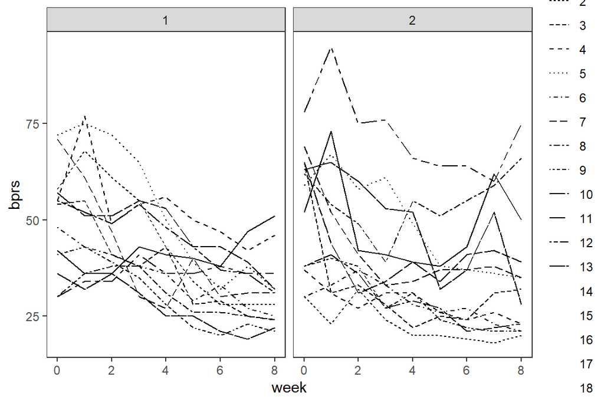

```r
# plot observed values
ggplot(BPRSL, aes(x = week, y = bprs, linetype = subject)) +
  geom_line() +
  facet_wrap(~treatment)
```

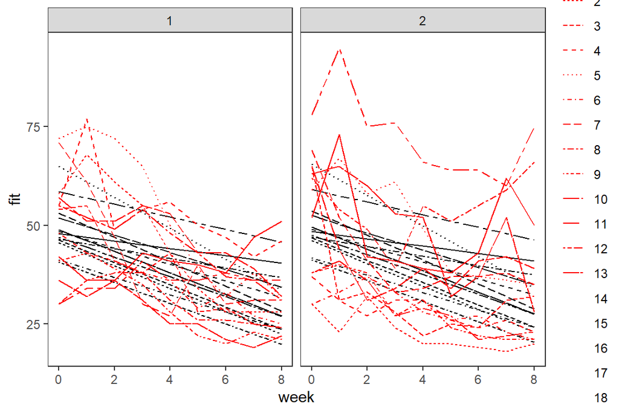

```r
# add fitted values from best model
Fitted <- fitted(BPRSL_ref1)
BPRSL <- BPRSL %>% mutate(fit = Fitted)

# plot observed and fitted values
ggplot(BPRSL, aes(x = week, y = fit, linetype = subject)) +
  geom_line() +
  facet_wrap(~treatment) +
  geom_line(aes(x = week, y = bprs, linetype = subject), color = 'red')
```

We added interactions of week and treatment to the Random Intercept and Random Slope Model. After computing the table of variance by accessing the summary of the anova I suggest that the model does not differ significantly from the other model because the p value is higher than 0.05. Nevertheless, the fit should be slightly better because of the lower Chisq value in comparison to above. All in all, I wouldn’t go on with the model including interaction but rather with the more parsimonous model without the interaction. Afterwards, I used the fitted values to show the model performance in comparison to the real values.